# Notebook

```
turning H bonds into constraints...
turning H bonds into constraints...
Analysing residue names:
There are:     3    Protein residues
There are:   523      Water residues
Analysing Protein...
Determining Verlet buffer for a tolerance of 0.005 kJ/mol/ps at 300 K
Calculated rlist for 1x1 atom pair-list as 1.036 nm, buffer size 0.036 nm
Set rlist, assuming 4x4 atom pair-list, to 1.000 nm, buffer size 0.000 nm
Note that mdrun will redetermine rlist based on the actual pair-list setup
Calculating fourier grid dimensions for X Y Z
Using a fourier grid of 24x24x24, spacing 0.118 0.118 0.118
This run will generate roughly 12 Mb of data
```

[output not shown]

[output cut: 54 more lines]

```
Working dir:  /scratch/bussi/masterclass-22-10-solution/2d/l0.7
Command line:
  gmx_mpi grompp -c ../../conf.gro -f ../../grompp.mdp

Setting the LD random seed to 1073568699
Generated 8515 of the 8515 non-bonded parameter combinations
Generating 1-4 interactions: fudge = 0.5
Generated 8515 of the 8515 1-4 parameter combinations
Excluding 3 bonded neighbours molecule type 'Protein'
Excluding 2 bonded neighbours molecule type 'SOL'
Number of degrees of freedom in T-Coupling group Protein is 53.95
Number of degrees of freedom in T-Coupling group SOL is 3135.05
Estimate for the relative computational load of the PME mesh part: 0.19

GROMACS reminds you: "Njuta men inte frossa, springa men inte fly" (Paganus)
```

```
turning H bonds into constraints...
turning H bonds into constraints...
Analysing residue names:
There are:     3    Protein residues
There are:   523      Water residues
Analysing Protein...
Determining Verlet buffer for a tolerance of 0.005 kJ/mol/ps at 300 K
Calculated rlist for 1x1 atom pair-list as 1.036 nm, buffer size 0.036 nm
Set rlist, assuming 4x4 atom pair-list, to 1.000 nm, buffer size 0.000 nm
Note that mdrun will redetermine rlist based on the actual pair-list setup
Calculating fourier grid dimensions for X Y Z
Using a fourier grid of 24x24x24, spacing 0.118 0.118 0.118
This run will generate roughly 12 Mb of data
```

[output not shown]

[output cut: 54 more lines]

```
Working dir:  /scratch/bussi/masterclass-22-10-solution/2d/l0.6
Command line:
  gmx_mpi grompp -c ../../conf.gro -f ../../grompp.mdp

Setting the LD random seed to -570726071
Generated 8515 of the 8515 non-bonded parameter combinations
Generating 1-4 interactions: fudge = 0.5
Generated 8515 of the 8515 1-4 parameter combinations
Excluding 3 bonded neighbours molecule type 'Protein'
Excluding 2 bonded neighbours molecule type 'SOL'
Number of degrees of freedom in T-Coupling group Protein is 53.95
Number of degrees of freedom in T-Coupling group SOL is 3135.05
Estimate for the relative computational load of the PME mesh part: 0.19

GROMACS reminds you: "It seemed a good idea at first" (Gerrit Groenhof)
```

```
turning H bonds into constraints...
turning H bonds into constraints...
Analysing residue names:
There are:     3    Protein residues
There are:   523      Water residues
Analysing Protein...
Determining Verlet buffer for a tolerance of 0.005 kJ/mol/ps at 300 K
Calculated rlist for 1x1 atom pair-list as 1.036 nm, buffer size 0.036 nm
Set rlist, assuming 4x4 atom pair-list, to 1.000 nm, buffer size 0.000 nm
Note that mdrun will redetermine rlist based on the actual pair-list setup
Calculating fourier grid dimensions for X Y Z
Using a fourier grid of 24x24x24, spacing 0.118 0.118 0.118
This run will generate roughly 12 Mb of data
```

[output not shown]

[output cut: 54 more lines]

```
Working dir:  /scratch/bussi/masterclass-22-10-solution/2d/l0.5
Command line:
  gmx_mpi grompp -c ../../conf.gro -f ../../grompp.mdp

Setting the LD random seed to -1199046787
Generated 8515 of the 8515 non-bonded parameter combinations
Generating 1-4 interactions: fudge = 0.5
Generated 8515 of the 8515 1-4 parameter combinations
Excluding 3 bonded neighbours molecule type 'Protein'
Excluding 2 bonded neighbours molecule type 'SOL'
Number of degrees of freedom in T-Coupling group Protein is 53.95
Number of degrees of freedom in T-Coupling group SOL is 3135.05
Estimate for the relative computational load of the PME mesh part: 0.19

GROMACS reminds you: "O My God, They Killed Kenny !" (South Park)
```

```
turning H bonds into constraints...
turning H bonds into constraints...
Analysing residue names:
There are:     3    Protein residues
There are:   523      Water residues
Analysing Protein...
Determining Verlet buffer for a tolerance of 0.005 kJ/mol/ps at 300 K
Calculated rlist for 1x1 atom pair-list as 1.036 nm, buffer size 0.036 nm
Set rlist, assuming 4x4 atom pair-list, to 1.000 nm, buffer size 0.000 nm
Note that mdrun will redetermine rlist based on the actual pair-list setup
Calculating fourier grid dimensions for X Y Z
Using a fourier grid of 24x24x24, spacing 0.118 0.118 0.118
This run will generate roughly 12 Mb of data
```

[output not shown]

[output cut: 54 more lines]

```
Working dir:  /scratch/bussi/masterclass-22-10-solution/2d/l0.4
Command line:
  gmx_mpi grompp -c ../../conf.gro -f ../../grompp.mdp

Setting the LD random seed to 2117074939
Generated 8515 of the 8515 non-bonded parameter combinations
Generating 1-4 interactions: fudge = 0.5
Generated 8515 of the 8515 1-4 parameter combinations
Excluding 3 bonded neighbours molecule type 'Protein'
Excluding 2 bonded neighbours molecule type 'SOL'
Number of degrees of freedom in T-Coupling group Protein is 53.95
Number of degrees of freedom in T-Coupling group SOL is 3135.05
Estimate for the relative computational load of the PME mesh part: 0.19

GROMACS reminds you: "I always think there is something foreign about jolly phrases at breakfast." (Mr. Carson in Downtown Abbey)
```

```
turning H bonds into constraints...
turning H bonds into constraints...
Analysing residue names:
There are:     3    Protein residues
There are:   523      Water residues
Analysing Protein...
Determining Verlet buffer for a tolerance of 0.005 kJ/mol/ps at 300 K
Calculated rlist for 1x1 atom pair-list as 1.036 nm, buffer size 0.036 nm
Set rlist, assuming 4x4 atom pair-list, to 1.000 nm, buffer size 0.000 nm
Note that mdrun will redetermine rlist based on the actual pair-list setup
Calculating fourier grid dimensions for X Y Z
Using a fourier grid of 24x24x24, spacing 0.118 0.118 0.118
This run will generate roughly 12 Mb of data
```

[output not shown]

[output cut: 54 more lines]

```
Working dir:  /scratch/bussi/masterclass-22-10-solution/2d/l0.3
Command line:
  gmx_mpi grompp -c ../../conf.gro -f ../../grompp.mdp

Setting the LD random seed to -103297707
Generated 8515 of the 8515 non-bonded parameter combinations
Generating 1-4 interactions: fudge = 0.5
Generated 8515 of the 8515 1-4 parameter combinations
Excluding 3 bonded neighbours molecule type 'Protein'
Excluding 2 bonded neighbours molecule type 'SOL'
Number of degrees of freedom in T-Coupling group Protein is 53.95
Number of degrees of freedom in T-Coupling group SOL is 3135.05
Estimate for the relative computational load of the PME mesh part: 0.19

GROMACS reminds you: "It has been discovered that C++ provides a remarkable facility for concealing the trivial details of a program - such as where its bugs are." (David Keppel)
```

```
turning H bonds into constraints...
turning H bonds into constraints...
Analysing residue names:
There are:     3    Protein residues
There are:   523      Water residues
Analysing Protein...
Determining Verlet buffer for a tolerance of 0.005 kJ/mol/ps at 300 K
Calculated rlist for 1x1 atom pair-list as 1.036 nm, buffer size 0.036 nm
Set rlist, assuming 4x4 atom pair-list, to 1.000 nm, buffer size 0.000 nm
Note that mdrun will redetermine rlist based on the actual pair-list setup
Calculating fourier grid dimensions for X Y Z
Using a fourier grid of 24x24x24, spacing 0.118 0.118 0.118
This run will generate roughly 12 Mb of data
```

[output not shown]

[output cut: 54 more lines]

```
Working dir:  /scratch/bussi/masterclass-22-10-solution/2d/l0.2
Command line:
  gmx_mpi grompp -c ../../conf.gro -f ../../grompp.mdp

Setting the LD random seed to 2134892479
Generated 8515 of the 8515 non-bonded parameter combinations
Generating 1-4 interactions: fudge = 0.5
Generated 8515 of the 8515 1-4 parameter combinations
Excluding 3 bonded neighbours molecule type 'Protein'
Excluding 2 bonded neighbours molecule type 'SOL'
Number of degrees of freedom in T-Coupling group Protein is 53.95
Number of degrees of freedom in T-Coupling group SOL is 3135.05
Estimate for the relative computational load of the PME mesh part: 0.19

GROMACS reminds you: "Install our Free Energy Patents app! There is energy all around us; and it's free! Free energy is everywhere, and all around you, just waiting to be extracted! Over 100+ free energy patents!" (Mind and Miracle Productions on Twitter, spamming a FEP thread)
```

```
turning H bonds into constraints...
turning H bonds into constraints...
Analysing residue names:
There are:     3    Protein residues
There are:   523      Water residues
Analysing Protein...
Determining Verlet buffer for a tolerance of 0.005 kJ/mol/ps at 300 K
Calculated rlist for 1x1 atom pair-list as 1.035 nm, buffer size 0.035 nm
Set rlist, assuming 4x4 atom pair-list, to 1.000 nm, buffer size 0.000 nm
Note that mdrun will redetermine rlist based on the actual pair-list setup
Calculating fourier grid dimensions for X Y Z
Using a fourier grid of 24x24x24, spacing 0.118 0.118 0.118
This run will generate roughly 12 Mb of data
```

[output not shown]

[output cut: 54 more lines]

```
Working dir:  /scratch/bussi/masterclass-22-10-solution/2d/l0.1
Command line:
  gmx_mpi grompp -c ../../conf.gro -f ../../grompp.mdp

Setting the LD random seed to 2113920127
Generated 8515 of the 8515 non-bonded parameter combinations
Generating 1-4 interactions: fudge = 0.5
Generated 8515 of the 8515 1-4 parameter combinations
Excluding 3 bonded neighbours molecule type 'Protein'
Excluding 2 bonded neighbours molecule type 'SOL'
Number of degrees of freedom in T-Coupling group Protein is 53.95
Number of degrees of freedom in T-Coupling group SOL is 3135.05
Estimate for the relative computational load of the PME mesh part: 0.19

GROMACS reminds you: "If you know you are on the right track, if you have this inner knowledge, then nobody can turn you off... no matter what they say." (Barbara McClintock)
```

```
turning H bonds into constraints...
turning H bonds into constraints...
Analysing residue names:
There are:     3    Protein residues
There are:   523      Water residues
Analysing Protein...
Determining Verlet buffer for a tolerance of 0.005 kJ/mol/ps at 300 K
Calculated rlist for 1x1 atom pair-list as 1.035 nm, buffer size 0.035 nm
Set rlist, assuming 4x4 atom pair-list, to 1.000 nm, buffer size 0.000 nm
Note that mdrun will redetermine rlist based on the actual pair-list setup
Calculating fourier grid dimensions for X Y Z
Using a fourier grid of 24x24x24, spacing 0.118 0.118 0.118
This run will generate roughly 12 Mb of data
```

[output not shown]

```python
colvar=[]

for l in lambdas:
    with cd("2d/l"+str(l)):
        with open("plumed.dat","w") as f:
                  print("""
MOLINFO STRUCTURE=../../ala.pdb
phi: TORSION ATOMS=@phi-2
psi: TORSION ATOMS=@psi-2
PRINT ARG=phi,psi FILE=COLVAR
                  """, file=f)
        subprocess.run("plumed driver --ixtc traj_comp.xtc --plumed plumed.dat",shell=True)
        colvar.append(plumed.read_as_pandas("COLVAR"))
```

[output not shown]

```
+++ Loading the PLUMED kernel runtime +++
+++ PLUMED_KERNEL="/net/sbp/sbpstore1/bussi/miniconda3/envs/plumed-masterclass-2022/lib/libplumedKernel.so" +++
```

[output not shown]

```
+++ Loading the PLUMED kernel runtime +++
+++ PLUMED_KERNEL="/net/sbp/sbpstore1/bussi/miniconda3/envs/plumed-masterclass-2022/lib/libplumedKernel.so" +++
```

[output not shown]

```
+++ Loading the PLUMED kernel runtime +++
+++ PLUMED_KERNEL="/net/sbp/sbpstore1/bussi/miniconda3/envs/plumed-masterclass-2022/lib/libplumedKernel.so" +++
```

[output not shown]

```
+++ Loading the PLUMED kernel runtime +++
+++ PLUMED_KERNEL="/net/sbp/sbpstore1/bussi/miniconda3/envs/plumed-masterclass-2022/lib/libplumedKernel.so" +++
```

[output not shown]

```
+++ Loading the PLUMED kernel runtime +++
+++ PLUMED_KERNEL="/net/sbp/sbpstore1/bussi/miniconda3/envs/plumed-masterclass-2022/lib/libplumedKernel.so" +++
```

[output not shown]

```
+++ Loading the PLUMED kernel runtime +++
+++ PLUMED_KERNEL="/net/sbp/sbpstore1/bussi/miniconda3/envs/plumed-masterclass-2022/lib/libplumedKernel.so" +++
```

[output not shown]

```
+++ Loading the PLUMED kernel runtime +++
+++ PLUMED_KERNEL="/net/sbp/sbpstore1/bussi/miniconda3/envs/plumed-masterclass-2022/lib/libplumedKernel.so" +++
```

[output not shown]

```
+++ Loading the PLUMED kernel runtime +++
+++ PLUMED_KERNEL="/net/sbp/sbpstore1/bussi/miniconda3/envs/plumed-masterclass-2022/lib/libplumedKernel.so" +++
```

[output not shown]

```
+++ Loading the PLUMED kernel runtime +++
+++ PLUMED_KERNEL="/net/sbp/sbpstore1/bussi/miniconda3/envs/plumed-masterclass-2022/lib/libplumedKernel.so" +++
```

[output not shown]

```
+++ Loading the PLUMED kernel runtime +++
+++ PLUMED_KERNEL="/net/sbp/sbpstore1/bussi/miniconda3/envs/plumed-masterclass-2022/lib/libplumedKernel.so" +++
```

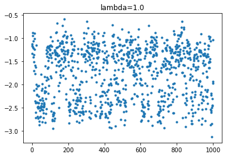

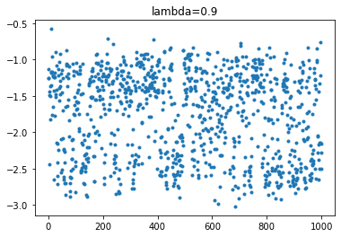

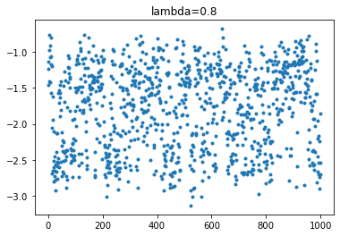

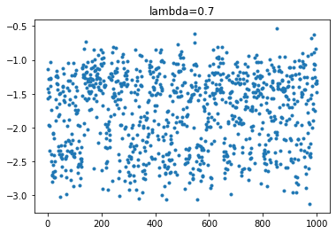

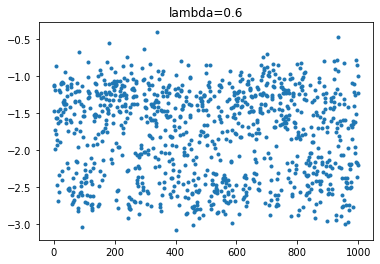

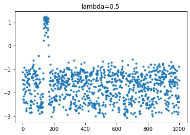

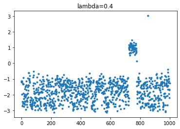

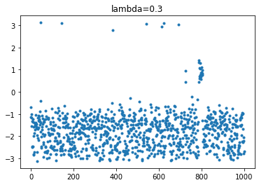

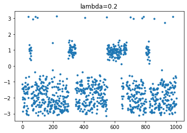

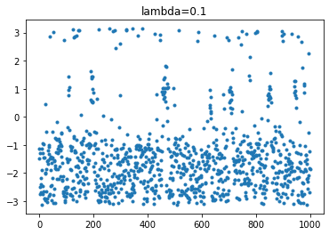

```python
for i in range(len(lambdas)):
    plt.title("lambda={}".format(lambdas[i]))
    plt.plot(colvar[i].time,colvar[i].phi,".")
    plt.show()
```

In any case, we expect the need to go to a lower scaling value in this case because solvent is not scaled at all. I will proceed with 0.15 as a reasonable choice

```python
300/800
```

```
0.375
```

## Exercise 3: Run Hamiltonian replica exchange simulations

Now that we chose the minumum lambda we can setup a tentative hrex simulation. I am trying first a linearly spacing lambda. By experience, linear spacing works better for lambda than logarithmic spacing (though this could be very system dependent!). In any case, we will see later how to optimize the lambda ladder if needed.

```python
lambda_min=0.15
lambdas=np.linspace(1.0,lambda_min,6)
```

```python
#this box takes a while to run
with cd("3/6reps"):
    with open("plumed.dat","w") as f:
        print("",file=f) # empty
    for i in range(len(lambdas)):
        with cd("replica{}".format(i)):
            run_mpi("cp ../../../2a/processed_selected.top processed_selected.top")
            run_mpi("plumed partial_tempering {} < processed_selected.top > topol.top".format(lambdas[i]))
            run_mpi("gmx_mpi grompp -c ../../../conf.gro -f ../../../grompp.mdp")
    run_mpi("gmx_mpi mdrun -multidir replica? -replex 200 -nsteps 500000 -ntomp 4 -hrex -plumed ../plumed.dat",len(lambdas))
```

[output not shown]

```
turning H bonds into constraints...
turning H bonds into constraints...
Analysing residue names:
There are:     3    Protein residues
There are:   523      Water residues
Analysing Protein...
Determining Verlet buffer for a tolerance of 0.005 kJ/mol/ps at 300 K
Calculated rlist for 1x1 atom pair-list as 1.036 nm, buffer size 0.036 nm
Set rlist, assuming 4x4 atom pair-list, to 1.000 nm, buffer size 0.000 nm
Note that mdrun will redetermine rlist based on the actual pair-list setup
Calculating fourier grid dimensions for X Y Z
Using a fourier grid of 24x24x24, spacing 0.118 0.118 0.118
This run will generate roughly 12 Mb of data
```

[output not shown]

```
turning H bonds into constraints...
turning H bonds into constraints...
Analysing residue names:
There are:     3    Protein residues
There are:   523      Water residues
Analysing Protein...
Determining Verlet buffer for a tolerance of 0.005 kJ/mol/ps at 300 K
Calculated rlist for 1x1 atom pair-list as 1.036 nm, buffer size 0.036 nm
Set rlist, assuming 4x4 atom pair-list, to 1.000 nm, buffer size 0.000 nm
Note that mdrun will redetermine rlist based on the actual pair-list setup
Calculating fourier grid dimensions for X Y Z
Using a fourier grid of 24x24x24, spacing 0.118 0.118 0.118
This run will generate roughly 12 Mb of data
```

[output not shown]

```
turning H bonds into constraints...
turning H bonds into constraints...
Analysing residue names:
There are:     3    Protein residues
There are:   523      Water residues
Analysing Protein...
Determining Verlet buffer for a tolerance of 0.005 kJ/mol/ps at 300 K
Calculated rlist for 1x1 atom pair-list as 1.036 nm, buffer size 0.036 nm
Set rlist, assuming 4x4 atom pair-list, to 1.000 nm, buffer size 0.000 nm
Note that mdrun will redetermine rlist based on the actual pair-list setup
Calculating fourier grid dimensions for X Y Z
Using a fourier grid of 24x24x24, spacing 0.118 0.118 0.118
This run will generate roughly 12 Mb of data
```

[output not shown]

```
turning H bonds into constraints...
turning H bonds into constraints...
Analysing residue names:
There are:     3    Protein residues
There are:   523      Water residues
Analysing Protein...
Determining Verlet buffer for a tolerance of 0.005 kJ/mol/ps at 300 K
Calculated rlist for 1x1 atom pair-list as 1.036 nm, buffer size 0.036 nm
Set rlist, assuming 4x4 atom pair-list, to 1.000 nm, buffer size 0.000 nm
Note that mdrun will redetermine rlist based on the actual pair-list setup
Calculating fourier grid dimensions for X Y Z
Using a fourier grid of 24x24x24, spacing 0.118 0.118 0.118
This run will generate roughly 12 Mb of data
```

[output not shown]

```
turning H bonds into constraints...
turning H bonds into constraints...
Analysing residue names:
There are:     3    Protein residues
There are:   523      Water residues
Analysing Protein...
Determining Verlet buffer for a tolerance of 0.005 kJ/mol/ps at 300 K
Calculated rlist for 1x1 atom pair-list as 1.036 nm, buffer size 0.036 nm
Set rlist, assuming 4x4 atom pair-list, to 1.000 nm, buffer size 0.000 nm
Note that mdrun will redetermine rlist based on the actual pair-list setup
Calculating fourier grid dimensions for X Y Z
Using a fourier grid of 24x24x24, spacing 0.118 0.118 0.118
This run will generate roughly 12 Mb of data
```

[output not shown]

```
turning H bonds into constraints...
turning H bonds into constraints...
Analysing residue names:
There are:     3    Protein residues
There are:   523      Water residues
Analysing Protein...
Determining Verlet buffer for a tolerance of 0.005 kJ/mol/ps at 300 K
Calculated rlist for 1x1 atom pair-list as 1.035 nm, buffer size 0.035 nm
Set rlist, assuming 4x4 atom pair-list, to 1.000 nm, buffer size 0.000 nm
Note that mdrun will redetermine rlist based on the actual pair-list setup
Calculating fourier grid dimensions for X Y Z
Using a fourier grid of 24x24x24, spacing 0.118 0.118 0.118
This run will generate roughly 12 Mb of data
```

[output not shown]

[output cut: 151 more lines]

[output not shown]

```python
! grep -A 4 average probabilities 3/6reps/replica0/md.log
```

```
grep: probabilities: No such file or directory
3/6reps/replica0/md.log:Repl  average probabilities:
3/6reps/replica0/md.log-Repl     0    1    2    3    4    5
3/6reps/replica0/md.log-Repl      .55  .47  .41  .30  .12
3/6reps/replica0/md.log-Repl  number of exchanges:
3/6reps/replica0/md.log-Repl     0    1    2    3    4    5
--
3/6reps/replica0/md.log:Repl  average number of exchanges:
3/6reps/replica0/md.log-Repl     0    1    2    3    4    5
3/6reps/replica0/md.log-Repl      .57  .46  .42  .30  .12
3/6reps/replica0/md.log-
3/6reps/replica0/md.log-
```

Accepntace is fine, except for in the last pair of replicas. We will fix this later.

We then read the resulting trajectories.

```python
colvar=[]

for i in range(len(lambdas)):
    with cd("3/6reps/replica"+str(i)):
        with open("plumed.dat","w") as f:
            print("""
MOLINFO STRUCTURE=../../../ala.pdb
phi: TORSION ATOMS=@phi-2
psi: TORSION ATOMS=@psi-2
PRINT ARG=phi,psi FILE=COLVAR
                  """,file=f)
        subprocess.run("plumed driver --ixtc traj_comp.xtc --plumed plumed.dat",shell=True)

        colvar.append(plumed.read_as_pandas("COLVAR"))
```

[output not shown]

```
+++ Loading the PLUMED kernel runtime +++
+++ PLUMED_KERNEL="/net/sbp/sbpstore1/bussi/miniconda3/envs/plumed-masterclass-2022/lib/libplumedKernel.so" +++
```

[output not shown]

```
+++ Loading the PLUMED kernel runtime +++
+++ PLUMED_KERNEL="/net/sbp/sbpstore1/bussi/miniconda3/envs/plumed-masterclass-2022/lib/libplumedKernel.so" +++
```

[output not shown]

```
+++ Loading the PLUMED kernel runtime +++
+++ PLUMED_KERNEL="/net/sbp/sbpstore1/bussi/miniconda3/envs/plumed-masterclass-2022/lib/libplumedKernel.so" +++
```

[output not shown]

[output cut: 35 more lines]

```
PLUMED: Action PRINT
PLUMED:   with label @3
PLUMED:   with stride 1
PLUMED:   with arguments phi psi
PLUMED:   on file COLVAR
PLUMED:   with format  %f
PLUMED: END FILE: plumed.dat
PLUMED: Timestep: 1.000000
PLUMED: KbT has not been set by the MD engine
PLUMED: It should be set by hand where needed
PLUMED: Relevant bibliography:
PLUMED:   [1] The PLUMED consortium, Nat. Methods 16, 670 (2019)
PLUMED:   [2] Tribello, Bonomi, Branduardi, Camilloni, and Bussi, Comput. Phys. Commun. 185, 604 (2014)
PLUMED: Please read and cite where appropriate!
PLUMED: Finished setup
```

```
+++ Loading the PLUMED kernel runtime +++
+++ PLUMED_KERNEL="/net/sbp/sbpstore1/bussi/miniconda3/envs/plumed-masterclass-2022/lib/libplumedKernel.so" +++
```

[output not shown]

```
+++ Loading the PLUMED kernel runtime +++
+++ PLUMED_KERNEL="/net/sbp/sbpstore1/bussi/miniconda3/envs/plumed-masterclass-2022/lib/libplumedKernel.so" +++
```

```
PLUMED:                                               Cycles        Total      Average      Minimum      Maximum
PLUMED:                                                    1     0.091703     0.091703     0.091703     0.091703
PLUMED: 1 Prepare dependencies                          1001     0.002012     0.000002     0.000001     0.000012
PLUMED: 2 Sharing data                                  1001     0.010086     0.000010     0.000009     0.000261
PLUMED: 3 Waiting for data                              1001     0.003393     0.000003     0.000003     0.000021
PLUMED: 4 Calculating (forward loop)                    1001     0.011303     0.000011     0.000011     0.000042
PLUMED: 5 Applying (backward loop)                      1001     0.014596     0.000015     0.000014     0.000030
PLUMED: 6 Update                                        1001     0.009471     0.000009     0.000008     0.000059
```

```
+++ Loading the PLUMED kernel runtime +++
+++ PLUMED_KERNEL="/net/sbp/sbpstore1/bussi/miniconda3/envs/plumed-masterclass-2022/lib/libplumedKernel.so" +++
```

It looks like there are transitions between the two minima (though probably not so many independent ones):

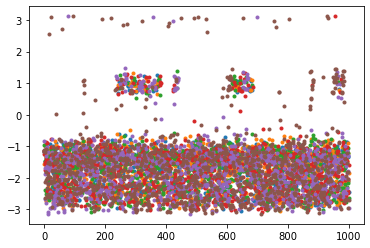

```python
for i in range(len(lambdas)):
    plt.plot(colvar[i].time,colvar[i].phi,".")
```

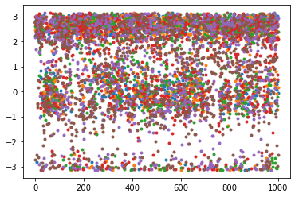

```python
for i in range(len(lambdas)):
    plt.plot(colvar[i].time,colvar[i].psi,".")
```

```python
pop_hrex=[]
for i in range(len(lambdas)):
    pop_hrex.append(
        np.sum(np.logical_and(colvar[i].phi<2.0,colvar[i].phi>0))/
        np.sum(np.logical_or(colvar[i].phi>2.0,colvar[i].phi<0))
    )
```

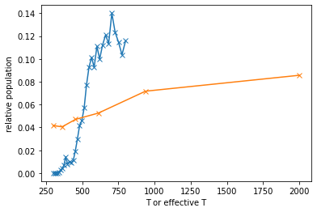

```python
plt.plot(Ts,pop_pt,"x-",label="pt")
plt.plot(Ts[0]/lambdas,pop_hrex,"x-",label="hrex")
plt.xlabel("T or effective T")
plt.ylabel("relative population")
plt.show()
```

Clearly populations are noisy. You might rerun these simulations longer to have better estimates. In any case, there is clearly some correlation between the results.

## Exercise 4: Analyze Hamiltonian replica exchange simulations with WHAM

We are now ready to use a full binless WHAM analysis to recover the maximum amount of statistics from our hrex simulation.

```python
# this box takes a while to run
with cd("3/6reps/"):
    run_mpi("gmx_mpi trjcat -cat -f replica?/traj_comp.xtc -o traj.xtc")
    for i in range(len(lambdas)):
        run_mpi("gmx_mpi mdrun -rerun traj.xtc -s replica{}/topol.tpr -e energy{}.edr".format(i,i))
        subprocess.run("echo 11 | gmx_mpi energy -f energy{}.edr -xvg no -o energy{}.xvg".format(i,i),shell=True)
```

[output not shown]

```
Note that major changes are planned in future for trjcat, to improve usability and utility.
lasttime 0
```

```
Last frame       1000 time 1000.000
Reading frame       0 time    0.000
Continue writing frames from replica1/traj_comp.xtc t=0 ps, frame=1001
 ->  frame   1320 time  319.000 ps
```

```
lasttime 1000
```

```
Last frame       1000 time 1000.000
Reading frame       0 time    0.000
Continue writing frames from replica2/traj_comp.xtc t=0 ps, frame=2002
 ->  frame   2440 time  438.000 ps
```

```
lasttime 1000
```

```
Last frame       1000 time 1000.000
Reading frame       0 time    0.000
Continue writing frames from replica3/traj_comp.xtc t=0 ps, frame=3003
Reading frame     150 time  150.000    ->  frame   3160 time  157.000 ps
```

```
lasttime 1000
```

```
Last frame       1000 time 1000.000
Reading frame       0 time    0.000
Continue writing frames from replica4/traj_comp.xtc t=0 ps, frame=4004
 ->  frame   4640 time  636.000 ps
```

```
lasttime 1000
```

```
Last frame       1000 time 1000.000
Reading frame       0 time    0.000
Continue writing frames from replica5/traj_comp.xtc t=0 ps, frame=5005
 ->  frame   5490 time  485.000 ps
```

```
lasttime 1000
```

[output not shown]

[output cut: 62 more lines]

```
  gmx_mpi energy -f energy0.edr -xvg no -o energy0.xvg

Opened energy0.edr as single precision energy file

Select the terms you want from the following list by
selecting either (part of) the name or the number or a combination.
End your selection with an empty line or a zero.
-------------------------------------------------------------------
  1  Bond             2  Angle            3  Proper-Dih.      4  Improper-Dih.
  5  LJ-14            6  Coulomb-14       7  LJ-(SR)          8  Disper.-corr.
  9  Coulomb-(SR)    10  Coul.-recip.    11  Potential

Last energy frame read 6005 time 1000.000

GROMACS reminds you: "I Can't Shake It" (Dinosaur Jr)
```

```
Statistics over 500001 steps [ 0.0000 through 1000.0000 ps ], 1 data sets
All statistics are over 6006 points (frames)

Energy                      Average   Err.Est.       RMSD  Tot-Drift
-------------------------------------------------------------------------------
Potential                    -21086        6.5    150.825   -4.68691  (kJ/mol)
```

[output not shown]

[output cut: 58 more lines]

```
  gmx_mpi energy -f energy1.edr -xvg no -o energy1.xvg

Opened energy1.edr as single precision energy file

Select the terms you want from the following list by
selecting either (part of) the name or the number or a combination.
End your selection with an empty line or a zero.
-------------------------------------------------------------------
  1  Bond             2  Angle            3  Proper-Dih.      4  Improper-Dih.
  5  LJ-14            6  Coulomb-14       7  LJ-(SR)          8  Disper.-corr.
  9  Coulomb-(SR)    10  Coul.-recip.    11  Potential

Last energy frame read 6005 time 1000.000

GROMACS reminds you: "We're Gonna Hit You Harder" (Scoter)
```

```
Statistics over 500001 steps [ 0.0000 through 1000.0000 ps ], 1 data sets
All statistics are over 6006 points (frames)

Energy                      Average   Err.Est.       RMSD  Tot-Drift
-------------------------------------------------------------------------------
Potential                  -21062.8        6.5    148.012    -4.5009  (kJ/mol)
```

[output not shown]

[output cut: 58 more lines]

```
  gmx_mpi energy -f energy2.edr -xvg no -o energy2.xvg

Opened energy2.edr as single precision energy file

Select the terms you want from the following list by
selecting either (part of) the name or the number or a combination.
End your selection with an empty line or a zero.
-------------------------------------------------------------------
  1  Bond             2  Angle            3  Proper-Dih.      4  Improper-Dih.
  5  LJ-14            6  Coulomb-14       7  LJ-(SR)          8  Disper.-corr.
  9  Coulomb-(SR)    10  Coul.-recip.    11  Potential

Last energy frame read 6005 time 1000.000

GROMACS reminds you: "BioBeat is Not Available In Regular Shops" (P.J. Meulenhoff)
```

```
Statistics over 500001 steps [ 0.0000 through 1000.0000 ps ], 1 data sets
All statistics are over 6006 points (frames)

Energy                      Average   Err.Est.       RMSD  Tot-Drift
-------------------------------------------------------------------------------
Potential                    -21038        6.5    145.506   -4.31978  (kJ/mol)
```

[output not shown]

[output cut: 58 more lines]

```
  gmx_mpi energy -f energy3.edr -xvg no -o energy3.xvg

Opened energy3.edr as single precision energy file

Select the terms you want from the following list by
selecting either (part of) the name or the number or a combination.
End your selection with an empty line or a zero.
-------------------------------------------------------------------
  1  Bond             2  Angle            3  Proper-Dih.      4  Improper-Dih.
  5  LJ-14            6  Coulomb-14       7  LJ-(SR)          8  Disper.-corr.
  9  Coulomb-(SR)    10  Coul.-recip.    11  Potential

Last energy frame read 6005 time 1000.000

GROMACS reminds you: "She Says She Can't Go Home Without a Chaperone" (E. Costello)
```

```
Statistics over 500001 steps [ 0.0000 through 1000.0000 ps ], 1 data sets
All statistics are over 6006 points (frames)

Energy                      Average   Err.Est.       RMSD  Tot-Drift
-------------------------------------------------------------------------------
Potential                  -21010.9        6.5    143.358   -4.14589  (kJ/mol)
```

[output not shown]

[output cut: 58 more lines]

```
  gmx_mpi energy -f energy4.edr -xvg no -o energy4.xvg

Opened energy4.edr as single precision energy file

Select the terms you want from the following list by
selecting either (part of) the name or the number or a combination.
End your selection with an empty line or a zero.
-------------------------------------------------------------------
  1  Bond             2  Angle            3  Proper-Dih.      4  Improper-Dih.
  5  LJ-14            6  Coulomb-14       7  LJ-(SR)          8  Disper.-corr.
  9  Coulomb-(SR)    10  Coul.-recip.    11  Potential

Last energy frame read 6005 time 1000.000

GROMACS reminds you: "Boom Boom Boom Boom, I Want You in My Room" (Venga Boys)
```

```
Statistics over 500001 steps [ 0.0000 through 1000.0000 ps ], 1 data sets
All statistics are over 6006 points (frames)

Energy                      Average   Err.Est.       RMSD  Tot-Drift
-------------------------------------------------------------------------------
Potential                    -20980        6.5    141.643   -3.98293  (kJ/mol)
```

[output not shown]

[output cut: 9 more lines]

```

Using 24 OpenMP threads

starting md rerun 'alanine dipeptide in vacuum in water', reading coordinates from input trajectory 'traj.xtc'

Reading frame    6000 time  995.000

NOTE: Detected invalid cycle counts, probably because threads moved between CPU cores that do not have synchronized cycle counters. Will not print the cycle accounting.

               Core t (s)   Wall t (s)        (%)
       Time:     1542.324       64.264     2400.0
                 (ns/day)    (hour/ns)
Performance:     1344.464        0.018

GROMACS reminds you: "Bad times have a scientific value. These are occasions a good learner would not miss." (Ralph Waldo Emerson)
```

```
Statistics over 500001 steps [ 0.0000 through 1000.0000 ps ], 1 data sets
All statistics are over 6006 points (frames)

Energy                      Average   Err.Est.       RMSD  Tot-Drift
-------------------------------------------------------------------------------
Potential                  -20941.7        6.5    140.521   -3.84269  (kJ/mol)
```

[output not shown]

```python
import wham
print(wham.__file__) # make sure you are using the wham script provided with this masterclass
energies=[]
with cd("3/6reps"):
    for i in range(len(lambdas)):
        energies.append(np.loadtxt("energy{}.xvg".format(i),usecols=1))
energies=np.array(energies).T
```

```
/scratch/bussi/masterclass-22-10-solution/wham.py
```

```python
energies.shape
```

```
(6006, 6)
```

```python
# energies[i,j] is the energy of frame i according to the j-th Hamiltonian
kBT=0.00831446261815324*300
w=wham.wham(energies,T=kBT)
# w["logW"] are the Boltzmann factors
# notice that we did not specify yet to which ensemble we are reweighting
# this can be done with the following line:
logW=w["logW"]-energies[:,0]/kBT
# logW are the logaritm weights to obtain properties corresponding to replica 0
logW-=np.max(logW) # avoid numerical errors in exp
weights=np.exp(logW)
weights/=np.sum(weights) # normalize weights
# these weights can be used to compute weighted averages
```

Now we plot the weights corresponding to the first replica. These weights can be obtained to compute averages in the reference ensemble

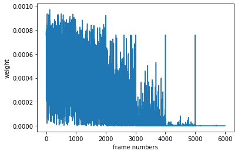

```python
plt.plot(weights)
plt.xlabel("frame numbers")
plt.ylabel("weight")
plt.show()
```

Clearly the weights decrease for frames corresponding to higher replicas.

Interestingly, the weight of a conformation depends only on the conformation, and not on the number of the frames. As a consequence, the very first frame of each replica, which was equilibrated using the reference potential energy, has a high weight. Probably these frames should be discarded, as system is not equilibrated yet. Anyway, they likely contribute very little to the weights.

The cumulative sum shows clear "kinks" when we pass from one of the replicas to the next one, showing that clearly the average weight depends on the replica index.

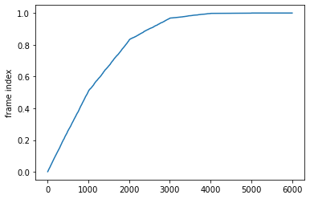

```python
plt.plot(np.cumsum(weights))
plt.ylabel("cumulative sum of weights")
plt.ylabel("frame index")
plt.show()
```

```python
c=[]
for i in range(len(colvar)):
    c.append(np.array(colvar[i].phi))
colvar_cat=np.hstack(c)
colvar_cat.shape
```

```
(6006,)
```

```python
np.array(colvar[i].phi)
print(
    np.sum(weights*np.logical_and(colvar_cat<2.0,colvar_cat>0))/
    np.sum(weights*np.logical_or(colvar_cat>2.0,colvar_cat<0))
)
```

```
0.043619042468797053
```

```python
weight_of_lambda=[]
for i in range(len(lambdas)):
    de=(-energies[:,i]+energies[:,0])/kBT
    weight_of_lambda.append(weights*np.exp(de-np.max(de))/np.sum(weights*np.exp(de-np.max(de))))


pop_wham=[]
for i in range(len(lambdas)):
    pop_wham.append(
        np.sum(weight_of_lambda[i]*np.logical_and(colvar_cat<2.0,colvar_cat>0))/
        np.sum(weight_of_lambda[i]*np.logical_or(colvar_cat>2.0,colvar_cat<0))
    )
```

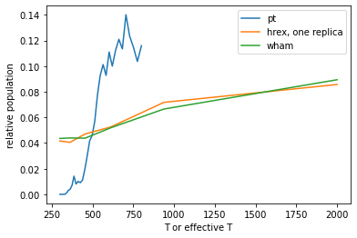

```python
plt.plot(Ts,pop_pt,label="pt")
plt.plot(Ts[0]/lambdas,pop_hrex,label="hrex, one replica")
plt.plot(Ts[0]/lambdas,pop_wham,label="wham")
plt.legend()
plt.xlabel("T or effective T")
plt.ylabel("relative population")
plt.show()
```

Notice that we can also plot the weights that allow to compute averages at replicas different from the first one.

From the plot below, you can easily see that when you compute weights corresponding to the higher replicas, the frames close to the end of the concatenated trajectory become more important.

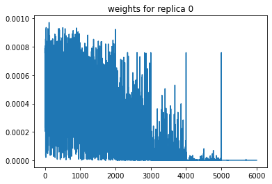

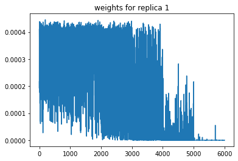

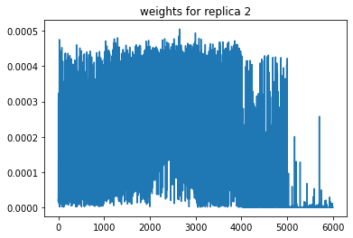

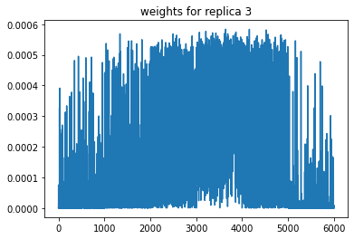

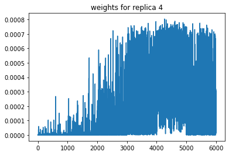

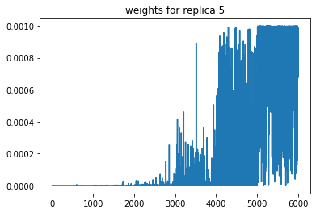

```python
for i in range(len(weight_of_lambda)):
    plt.title("weights for replica {}".format(i))
    plt.plot(weight_of_lambda[i])
    plt.show()
```

## Exercise 5: Optimize the lambda ladder

We next try to optimize the lambda ladder. To do so, we will run a minimization procedure. In this minimization we should be able to compute averages corresponding to new values of lambda (including values *not* simulated yet!) quickly. To do so, we realize that the energy of a frame is a quadratic function of the sqrt(lambda).

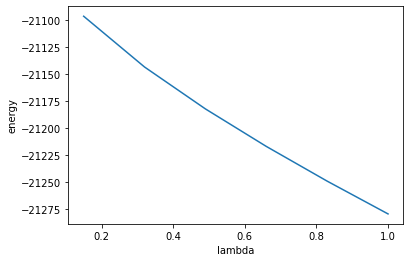

```python
# this is what we see plotting energy as a function of lambda for a random frame
plt.plot(lambdas,energies[100])
plt.xlabel("lambda")
plt.ylabel("energy")
plt.show()
```

One might think that energy should decrease monotonously with lambda based on the plot above. However, we can just search from frames where this is not true.

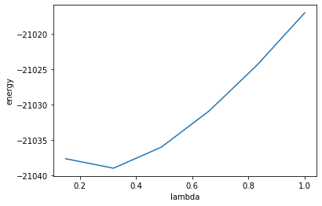

```python
check=[]
for i in range(energies.shape[0]):
    ok=False
    for j in range(energies.shape[1]-1):
        if(energies[i,j]>energies[i,j+1]):
            ok=True
    if ok:
        check.append(i)
check[0]
plt.plot(lambdas,energies[check[0],:])
# this is just one for example
plt.xlabel("lambda")
plt.ylabel("energy")
plt.show()
```

Then, for each frame, we fit the coefficients of the function that allows us to recompute energies for arbitrary values of lambda

```python
coefficients=[]
for i in range(energies.shape[0]):
    c=np.polyfit(np.sqrt(lambdas),energies[i],2)
    coefficients.append(c)
coefficients=np.array(coefficients)
residual=np.dot(coefficients,
                np.array((lambdas,np.sqrt(lambdas),np.ones(len(lambdas)))))-energies
```

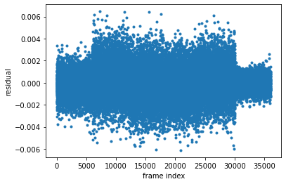

```python
# This is the residual, very small
plt.plot(residual.T.flatten(),".")
plt.xlabel("frame index")
plt.ylabel("residual")
plt.show()
```

Now we can write a function that predicts the acceptance between two arbitrary values of lambda

```python
def predict_acceptance(l1,l2):
    # energies corresponding to l1 and l2, using the interpolated function
    e1=coefficients[:,0]*l1+coefficients[:,1]*np.sqrt(l1)+coefficients[:,2]
    e2=coefficients[:,0]*l2+coefficients[:,1]*np.sqrt(l2)+coefficients[:,2]

    # weights corresponding to l1 and l2
    logW1=w["logW"]-e1/kBT
    logW2=w["logW"]-e2/kBT
    logW1-=np.max(logW1)
    logW2-=np.max(logW2)
    w1=np.exp(logW1)
    w2=np.exp(logW2)
    w1/=np.sum(w1)
    w2/=np.sum(w2)

    # then we have to compute the average of the acceptance, which means the average of:
    # np.minimum(w1[j]*w2[i]/(w1[i]*w2[j]),1.0)
    # (compare with Metropolis rule)

    # We can do it in two ways. One way is to randomly sample a number (10000, below)
    # of frames from the two ensembles and using them to compute the average acceptance.

    #c1=np.random.choice(len(w1),10000,p=w1)
    #c2=np.random.choice(len(w2),10000,p=w2)
    #a=np.minimum(w1[c2]*w2[c1]/(w1[c1]*w2[c2]),1.0)
    #return np.average(a)

    # the problem of this approach is that it is random, thus not good to construct a function to be minimized

    # alternatively we consider all pairs of frame, with a skip (5) here to just run faster
    w1=w1[::5]
    w2=w2[::5]
    a=[]
    for i in range(len(w1)):
        a.append(np.average(np.minimum(w1[:]*w2[i]/(w1[i]*w2[:]),1.0),weights=w2))
    return np.average(a,weights=w1)
```

We can now try to "predict" the acceptance corresponding to the simulated lambdas:

```python
for i in range(len(lambdas)-1):
    print(predict_acceptance(lambdas[i],lambdas[i+1]))
```

```
0.5340728519771433
0.4940495074929892
0.39317545103849977
0.2990660445826373
0.11859391076651352
```

```python
!grep -A 3 "Repl  average probabilities" 3/6reps/replica0/md.log
```

```
Repl  average probabilities:
Repl     0    1    2    3    4    5
Repl      .55  .47  .41  .30  .12
Repl  number of exchanges:
```

Results are very close to the observed averages!

For instance, these would be the acceptance rates predicted for a *geometric* (rather than *linear*) arrangement of lambdas

```python
geometric_lambdas=np.geomspace(1.0,lambdas[-1],len(lambdas))
for i in range(len(lambdas)-1):
    print(predict_acceptance(geometric_lambdas[i],geometric_lambdas[i+1]))
```

```
0.2308635220970505
0.2783660937613743
0.3601825408394625
0.405309116856007
0.46225107980567376
```

The acceptance rates are more even. However, they kind of suffer the opposite problem, namely, acceptance is lower at low replicas. The ladder giving homogeneous rates is somewhere in between linear and geometric.

```python
# lambda is the array with the replicas we used for out simulation (a starting point(
# first and last replicas are fixed (1.0 and lambda_min)
# we thus optimize all elements excluding the first and the last (lambda[1:-1])

lambda_min=lambdas[-1]

# this function compute the acceptances given the three intermediate values of
# lambda
def predict_all_acceptances(x):
    x=np.array(x)
    acc=[]
    # lambdas should not be negative
    if np.any(x<=0.0):
        return np.zeros(len(x)+1)
    # nor larger than 1
    if np.any(x>=1.0):
        return np.zeros(len(x)+1)
    # first replica has lambda=1.0
    acc.append(predict_acceptance(1.0,x[0]))
    for i in range(len(x)-1):
        acc.append(predict_acceptance(x[i],x[i+1]))
    # last replica has lambda=lambda_min
    acc.append(predict_acceptance(x[-1],lambda_min))
    return acc

# this is function to be minimized
def func(x):
    acc=predict_all_acceptances(x)
    print(np.prod(acc)**(1/len(acc)))
    return -np.prod(acc) # negative, since we minimize the result

from scipy.optimize import minimize
res=minimize(func,lambdas[1:-1]) # starting values
optimal_lambdas=np.hstack((1.0,res.x,lambda_min))

print("optimal lambdas: ",optimal_lambdas)
print(predict_all_acceptances(res.x))
```

```
0.3259547940141271
0.325954793893094
0.3259547933599866
0.32595479341658784
0.32595479063001087
0.32872898680400764
0.3287289866628208
0.3287289861609084
0.32872898589937016
0.32872898428899244
0.3324338906848852
0.332433890492614
0.3324338900161506
0.332433889264336
0.33243389043460636
0.3335674496997589
0.3335674494601702
0.3335674489523692
0.33356744824582124
0.3335674507617446
0.33492136496655117
0.3349213646673383
0.3349213641049616
0.3349213638673992
0.33492136635635655
0.3370537872278969
0.33705378681141973
0.33705378622693233
0.3370537869108689
0.33705378833631455
0.3387366060583005
0.33873660542528716
0.3387366051464819
0.33873660690403357
0.338736606139612
0.3392440704975935
0.33924406983730954
0.3392440698256017
0.3392440712567459
0.3392440704650873
```

[output cut: 22 more lines]

```
0.3411313735570486
0.3411313735160984
0.34113137353392803
0.3411321736743728
0.3411321736759918
0.3411321736790199
0.3411321736687054
0.3411321736721058
0.34113221701542207
0.34113221701546226
0.341132217015375
0.3411322170154294
0.3411322170153383
optimal lambdas:  [1.         0.7490915  0.54002926 0.37503371 0.24605241 0.15      ]
[0.34973133878840834, 0.3417108301273635, 0.34368442978425084, 0.3414464459182263, 0.3294108774587619]
```

Predicted acceptance are all ~ 0.33.

Below we compare the possible ladders (linear, geometric, and optimal)

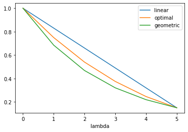

```python
plt.plot(lambdas,label="linear")
plt.plot(optimal_lambdas,label="optimal")
plt.plot(np.geomspace(1.0,lambdas[-1],len(lambdas)),label="geometric")
plt.legend()
plt.xlabel("replica index")
plt.xlabel("lambda")
plt.show()
```

## Exercise 6: Combine with metadynamics on psi

We next run a metadynamics + solute tempering simulation on psi.

Notice that psi is a **bad** variable for metadynamics on alanine dipeptide.

```python
# hardcoded here if I don't want to rerun previous boxes
optimal_lambdas=np.array([1.,0.7490915,0.54002926,0.37503371,0.24605241,0.15])
```

```python
# this takes a while
with cd("5/6reps"):
    with open("plumed.dat","w") as f:
        print("""
# vim:ft=plumed
MOLINFO STRUCTURE=../../../ala.pdb
phi: TORSION ATOMS=@phi-2
psi: TORSION ATOMS=@psi-2
# You can use the same parameters that you used in masterclass 21.4
m: METAD ...
   ARG=psi
   SIGMA=0.3
   HEIGHT=1.2
   BIASFACTOR=8
   PACE=500
   GRID_MIN=-pi
   GRID_MAX=pi
   FILE=../HILLS_PTMETAD
...
PRINT ARG=phi,psi FILE=../colvar_ptmetad.dat STRIDE=100
        """,file=f) # empty
    for i in range(len(optimal_lambdas)):
        with cd("replica{}".format(i)):
            run_mpi("cp ../../../2a/processed_selected.top processed_selected.top")
            run_mpi("plumed partial_tempering {} < processed_selected.top > topol.top".format(optimal_lambdas[i]))
            run_mpi("gmx_mpi grompp -c ../../../conf.gro -f ../../../grompp.mdp")
    run_mpi("gmx_mpi mdrun -multidir replica? -replex 200 -nsteps 500000 -ntomp 4 -hrex -plumed ../plumed.dat",len(lambdas))
```

[output not shown]

```
turning H bonds into constraints...
turning H bonds into constraints...
Analysing residue names:
There are:     3    Protein residues
There are:   523      Water residues
Analysing Protein...
Determining Verlet buffer for a tolerance of 0.005 kJ/mol/ps at 300 K
Calculated rlist for 1x1 atom pair-list as 1.036 nm, buffer size 0.036 nm
Set rlist, assuming 4x4 atom pair-list, to 1.000 nm, buffer size 0.000 nm
Note that mdrun will redetermine rlist based on the actual pair-list setup
Calculating fourier grid dimensions for X Y Z
Using a fourier grid of 24x24x24, spacing 0.118 0.118 0.118
This run will generate roughly 12 Mb of data
```

[output not shown]

```
turning H bonds into constraints...
turning H bonds into constraints...
Analysing residue names:
There are:     3    Protein residues
There are:   523      Water residues
Analysing Protein...
Determining Verlet buffer for a tolerance of 0.005 kJ/mol/ps at 300 K
Calculated rlist for 1x1 atom pair-list as 1.036 nm, buffer size 0.036 nm
Set rlist, assuming 4x4 atom pair-list, to 1.000 nm, buffer size 0.000 nm
Note that mdrun will redetermine rlist based on the actual pair-list setup
Calculating fourier grid dimensions for X Y Z
Using a fourier grid of 24x24x24, spacing 0.118 0.118 0.118
This run will generate roughly 12 Mb of data
```

[output not shown]

```
turning H bonds into constraints...
turning H bonds into constraints...
Analysing residue names:
There are:     3    Protein residues
There are:   523      Water residues
Analysing Protein...
Determining Verlet buffer for a tolerance of 0.005 kJ/mol/ps at 300 K
Calculated rlist for 1x1 atom pair-list as 1.036 nm, buffer size 0.036 nm
Set rlist, assuming 4x4 atom pair-list, to 1.000 nm, buffer size 0.000 nm
Note that mdrun will redetermine rlist based on the actual pair-list setup
Calculating fourier grid dimensions for X Y Z
Using a fourier grid of 24x24x24, spacing 0.118 0.118 0.118
This run will generate roughly 12 Mb of data
```

[output not shown]

```
turning H bonds into constraints...
turning H bonds into constraints...
Analysing residue names:
There are:     3    Protein residues
There are:   523      Water residues
Analysing Protein...
Determining Verlet buffer for a tolerance of 0.005 kJ/mol/ps at 300 K
Calculated rlist for 1x1 atom pair-list as 1.036 nm, buffer size 0.036 nm
Set rlist, assuming 4x4 atom pair-list, to 1.000 nm, buffer size 0.000 nm
Note that mdrun will redetermine rlist based on the actual pair-list setup
Calculating fourier grid dimensions for X Y Z
Using a fourier grid of 24x24x24, spacing 0.118 0.118 0.118
This run will generate roughly 12 Mb of data
```

[output not shown]

```
turning H bonds into constraints...
turning H bonds into constraints...
Analysing residue names:
There are:     3    Protein residues
There are:   523      Water residues
Analysing Protein...
Determining Verlet buffer for a tolerance of 0.005 kJ/mol/ps at 300 K
Calculated rlist for 1x1 atom pair-list as 1.036 nm, buffer size 0.036 nm
Set rlist, assuming 4x4 atom pair-list, to 1.000 nm, buffer size 0.000 nm
Note that mdrun will redetermine rlist based on the actual pair-list setup
Calculating fourier grid dimensions for X Y Z
Using a fourier grid of 24x24x24, spacing 0.118 0.118 0.118
This run will generate roughly 12 Mb of data
```

[output not shown]

```
turning H bonds into constraints...
turning H bonds into constraints...
Analysing residue names:
There are:     3    Protein residues
There are:   523      Water residues
Analysing Protein...
Determining Verlet buffer for a tolerance of 0.005 kJ/mol/ps at 300 K
Calculated rlist for 1x1 atom pair-list as 1.035 nm, buffer size 0.035 nm
Set rlist, assuming 4x4 atom pair-list, to 1.000 nm, buffer size 0.000 nm
Note that mdrun will redetermine rlist based on the actual pair-list setup
Calculating fourier grid dimensions for X Y Z
Using a fourier grid of 24x24x24, spacing 0.118 0.118 0.118
This run will generate roughly 12 Mb of data
```

[output not shown]

[output cut: 147 more lines]

[output not shown]

Nicely, the acceptance are in agreement with our prediction

```python
!grep -A 3 "Repl  average probabilities" 5/6reps/replica0/md.log
```

```
Repl  average probabilities:
Repl     0    1    2    3    4    5
Repl      .34  .34  .32  .35  .33
Repl  number of exchanges:
```

```python
colvar=[]

for i in range(len(optimal_lambdas)):
    with cd("5/6reps/replica"+str(i)):
        with open("plumed_plot.dat","w") as f:
            print("""
MOLINFO STRUCTURE=../../../ala.pdb
phi: TORSION ATOMS=@phi-2
psi: TORSION ATOMS=@psi-2
PRINT ARG=phi,psi FILE=COLVAR
                  """,file=f)
        subprocess.run("plumed driver --ixtc traj_comp.xtc --plumed plumed_plot.dat",shell=True)

        colvar.append(plumed.read_as_pandas("COLVAR"))
```

[output not shown]

```
+++ Loading the PLUMED kernel runtime +++
+++ PLUMED_KERNEL="/net/sbp/sbpstore1/bussi/miniconda3/envs/plumed-masterclass-2022/lib/libplumedKernel.so" +++
```

[output not shown]

[output cut: 35 more lines]

[output not shown]

```
+++ Loading the PLUMED kernel runtime +++
+++ PLUMED_KERNEL="/net/sbp/sbpstore1/bussi/miniconda3/envs/plumed-masterclass-2022/lib/libplumedKernel.so" +++
```

```
PLUMED:                                               Cycles        Total      Average      Minimum      Maximum
PLUMED:                                                    1     0.091335     0.091335     0.091335     0.091335
PLUMED: 1 Prepare dependencies                          1001     0.002040     0.000002     0.000002     0.000013
PLUMED: 2 Sharing data                                  1001     0.010122     0.000010     0.000009     0.000279
PLUMED: 3 Waiting for data                              1001     0.003369     0.000003     0.000003     0.000020
PLUMED: 4 Calculating (forward loop)                    1001     0.011145     0.000011     0.000010     0.000043
PLUMED: 5 Applying (backward loop)                      1001     0.014699     0.000015     0.000014     0.000026
PLUMED: 6 Update                                        1001     0.009292     0.000009     0.000008     0.000056
```

```
+++ Loading the PLUMED kernel runtime +++
+++ PLUMED_KERNEL="/net/sbp/sbpstore1/bussi/miniconda3/envs/plumed-masterclass-2022/lib/libplumedKernel.so" +++
```

[output not shown]

```
+++ Loading the PLUMED kernel runtime +++
+++ PLUMED_KERNEL="/net/sbp/sbpstore1/bussi/miniconda3/envs/plumed-masterclass-2022/lib/libplumedKernel.so" +++
```

[output not shown]

```
+++ Loading the PLUMED kernel runtime +++
+++ PLUMED_KERNEL="/net/sbp/sbpstore1/bussi/miniconda3/envs/plumed-masterclass-2022/lib/libplumedKernel.so" +++
```

[output not shown]

```
+++ Loading the PLUMED kernel runtime +++
+++ PLUMED_KERNEL="/net/sbp/sbpstore1/bussi/miniconda3/envs/plumed-masterclass-2022/lib/libplumedKernel.so" +++
```

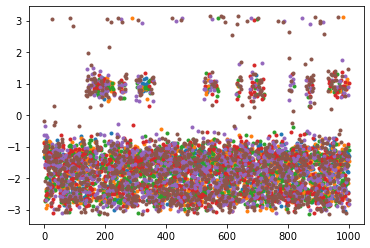

```python
for i in range(len(optimal_lambdas)):
    plt.plot(colvar[i].time,colvar[i].phi,".")
```

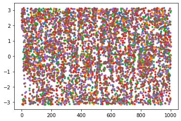

```python
for i in range(len(lambdas)):
    plt.plot(colvar[i].time,colvar[i].psi,".")
```

Then we concatenate the trajectories to do a WHAM analysis. We also use `mdrun -rerun` to compute energies corresponding to all replicas. In theory, we could do this for 3 replicas only and then interpolate the other values using the trick that we have used in the previous exercise. For simplicitly, we here just rerun with all topologies.

```python
# this takes a while
with cd("5/6reps/"):
    run_mpi("gmx_mpi trjcat -cat -f replica?/traj_comp.xtc -o traj.xtc")
    for i in range(len(optimal_lambdas)):
        run_mpi("gmx_mpi mdrun -rerun traj.xtc -s replica{}/topol.tpr -e energy{}.edr".format(i,i))
        subprocess.run("echo 11 | gmx_mpi energy -f energy{}.edr -xvg no -o energy{}.xvg".format(i,i),shell=True)
```

[output not shown]

```
Note that major changes are planned in future for trjcat, to improve usability and utility.
lasttime 0
```

```
Last frame       1000 time 1000.000
Reading frame       0 time    0.000
Continue writing frames from replica1/traj_comp.xtc t=0 ps, frame=1001
Reading frame     300 time  300.000    ->  frame   1310 time  309.000 ps
```

```
lasttime 1000
```

```
Last frame       1000 time 1000.000
Reading frame       0 time    0.000
Continue writing frames from replica2/traj_comp.xtc t=0 ps, frame=2002
Reading frame      20 time   20.000
```

```
lasttime 1000
```

```
Last frame       1000 time 1000.000
Reading frame       0 time    0.000
Continue writing frames from replica3/traj_comp.xtc t=0 ps, frame=3003
Reading frame     130 time  130.000
```

```
lasttime 1000
```

```
Last frame       1000 time 1000.000
Reading frame       0 time    0.000
Continue writing frames from replica4/traj_comp.xtc t=0 ps, frame=4004
 ->  frame   4550 time  546.000 ps
```

```
lasttime 1000
```

```
Last frame       1000 time 1000.000
Reading frame       0 time    0.000
Continue writing frames from replica5/traj_comp.xtc t=0 ps, frame=5005
 ->  frame   5260 time  255.000 ps
```

```
lasttime 1000
```

[output not shown]

[output cut: 62 more lines]

```
  gmx_mpi energy -f energy0.edr -xvg no -o energy0.xvg

Opened energy0.edr as single precision energy file

Select the terms you want from the following list by
selecting either (part of) the name or the number or a combination.
End your selection with an empty line or a zero.
-------------------------------------------------------------------
  1  Bond             2  Angle            3  Proper-Dih.      4  Improper-Dih.
  5  LJ-14            6  Coulomb-14       7  LJ-(SR)          8  Disper.-corr.
  9  Coulomb-(SR)    10  Coul.-recip.    11  Potential

Last energy frame read 6005 time 1000.000

GROMACS reminds you: "If you want to save your child from polio, you can pray or you can inoculate... choose science." (Carl Sagan)
```

```
Statistics over 500001 steps [ 0.0000 through 1000.0000 ps ], 1 data sets
All statistics are over 6006 points (frames)

Energy                      Average   Err.Est.       RMSD  Tot-Drift
-------------------------------------------------------------------------------
Potential                  -21069.8        4.4    150.963     5.5878  (kJ/mol)
```

[output not shown]

[output cut: 58 more lines]

```
  gmx_mpi energy -f energy1.edr -xvg no -o energy1.xvg

Opened energy1.edr as single precision energy file

Select the terms you want from the following list by
selecting either (part of) the name or the number or a combination.
End your selection with an empty line or a zero.
-------------------------------------------------------------------
  1  Bond             2  Angle            3  Proper-Dih.      4  Improper-Dih.
  5  LJ-14            6  Coulomb-14       7  LJ-(SR)          8  Disper.-corr.
  9  Coulomb-(SR)    10  Coul.-recip.    11  Potential

Last energy frame read 6005 time 1000.000

GROMACS reminds you: "You can get into a habit of thought in which you enjoy making fun of all those other people who don't see things as clearly as you do. We have to guard carefully against it." (Carl Sagan)
```

```
Statistics over 500001 steps [ 0.0000 through 1000.0000 ps ], 1 data sets
All statistics are over 6006 points (frames)

Energy                      Average   Err.Est.       RMSD  Tot-Drift
-------------------------------------------------------------------------------
Potential                  -21038.1        4.2    146.892    4.43208  (kJ/mol)
```

[output not shown]

[output cut: 58 more lines]

```
  gmx_mpi energy -f energy2.edr -xvg no -o energy2.xvg

Opened energy2.edr as single precision energy file

Select the terms you want from the following list by
selecting either (part of) the name or the number or a combination.
End your selection with an empty line or a zero.
-------------------------------------------------------------------
  1  Bond             2  Angle            3  Proper-Dih.      4  Improper-Dih.
  5  LJ-14            6  Coulomb-14       7  LJ-(SR)          8  Disper.-corr.
  9  Coulomb-(SR)    10  Coul.-recip.    11  Potential

Last energy frame read 6005 time 1000.000

GROMACS reminds you: "It's So Lonely When You Don't Even Know Yourself" (Red Hot Chili Peppers)
```

```
Statistics over 500001 steps [ 0.0000 through 1000.0000 ps ], 1 data sets
All statistics are over 6006 points (frames)

Energy                      Average   Err.Est.       RMSD  Tot-Drift
-------------------------------------------------------------------------------
Potential                  -21008.6        4.1    144.031    3.43349  (kJ/mol)
```

[output not shown]

[output cut: 58 more lines]

```
  gmx_mpi energy -f energy3.edr -xvg no -o energy3.xvg

Opened energy3.edr as single precision energy file

Select the terms you want from the following list by
selecting either (part of) the name or the number or a combination.
End your selection with an empty line or a zero.
-------------------------------------------------------------------
  1  Bond             2  Angle            3  Proper-Dih.      4  Improper-Dih.
  5  LJ-14            6  Coulomb-14       7  LJ-(SR)          8  Disper.-corr.
  9  Coulomb-(SR)    10  Coul.-recip.    11  Potential

Last energy frame read 6005 time 1000.000

GROMACS reminds you: "Take what you want, but just what you need for survival" (Joe Jackson)
```

```
Statistics over 500001 steps [ 0.0000 through 1000.0000 ps ], 1 data sets
All statistics are over 6006 points (frames)

Energy                      Average   Err.Est.       RMSD  Tot-Drift
-------------------------------------------------------------------------------
Potential                  -20982.2          4    142.196    2.60811  (kJ/mol)
```

[output not shown]

[output cut: 58 more lines]

```
  gmx_mpi energy -f energy4.edr -xvg no -o energy4.xvg

Opened energy4.edr as single precision energy file

Select the terms you want from the following list by
selecting either (part of) the name or the number or a combination.
End your selection with an empty line or a zero.
-------------------------------------------------------------------
  1  Bond             2  Angle            3  Proper-Dih.      4  Improper-Dih.
  5  LJ-14            6  Coulomb-14       7  LJ-(SR)          8  Disper.-corr.
  9  Coulomb-(SR)    10  Coul.-recip.    11  Potential

Last energy frame read 6005 time 1000.000

GROMACS reminds you: "Push It Real Good" (Salt 'n' Pepa)
```

```
Statistics over 500001 steps [ 0.0000 through 1000.0000 ps ], 1 data sets
All statistics are over 6006 points (frames)

Energy                      Average   Err.Est.       RMSD  Tot-Drift
-------------------------------------------------------------------------------
Potential                  -20958.2          4    141.092    1.92307  (kJ/mol)
```

[output not shown]

[output cut: 9 more lines]

```

Using 24 OpenMP threads

starting md rerun 'alanine dipeptide in vacuum in water', reading coordinates from input trajectory 'traj.xtc'

Reading frame    6000 time  995.000

NOTE: Detected invalid cycle counts, probably because threads moved between CPU cores that do not have synchronized cycle counters. Will not print the cycle accounting.

               Core t (s)   Wall t (s)        (%)
       Time:     1547.108       64.463     2400.0
                 (ns/day)    (hour/ns)
Performance:     1340.305        0.018

GROMACS reminds you: "We All Get the Flu, We All Get Aids" (LIVE)
```

```
Statistics over 500001 steps [ 0.0000 through 1000.0000 ps ], 1 data sets
All statistics are over 6006 points (frames)

Energy                      Average   Err.Est.       RMSD  Tot-Drift
-------------------------------------------------------------------------------
Potential                  -20936.8        3.9    140.529    1.37059  (kJ/mol)
```

[output not shown]

Additionally, we have to compute the value of the bias potential according to all replicas

```python
# this also takes a while
with cd("5/6reps/"):
    with open("plumed_ptmetad_process.dat","w") as f:
        print("""
# vim:ft=plumed
MOLINFO STRUCTURE=../../ala.pdb
phi: TORSION ATOMS=@phi-2
psi: TORSION ATOMS=@psi-2
m: METAD ...
   ARG=psi
   SIGMA=0.3
   HEIGHT=0.0
   BIASFACTOR=8
   PACE=5000000
   GRID_MIN=-pi
   GRID_MAX=pi
   FILE=HILLS_PTMETAD
   RESTART=YES
   TEMP=300
...
PRINT ARG=phi,psi,m.bias FILE=colvar_ptmetad_concat.dat
""".format(i,i),file=f)
    run_mpi("plumed driver --multi {} --plumed plumed_ptmetad_process.dat --ixtc traj.xtc".format(len(optimal_lambdas)),len(optimal_lambdas))
```

[output not shown]

[output cut: 359 more lines]

[output not shown]

Then we read all the calculated energies

```python
energies=[]
bias=[]
with cd("5/6reps"):
    for i in range(len(optimal_lambdas)):
        energies.append(np.loadtxt("energy{}.xvg".format(i),usecols=1))
        bias.append(plumed.read_as_pandas("colvar_ptmetad_concat.{}.dat".format(i))["m.bias"])
energies=np.array(energies).T
bias=np.array(bias).T
energies.shape,bias.shape
```

[output not shown]

```
((6006, 6), (6006, 6))
```

```python
import wham
kBT=0.00831446261815324*300
w=wham.wham(energies+bias,T=kBT)
# w["logW"] are the Boltzmann factors
# notice that we did not specify yet to which ensemble we are reweighting
# this can be done with the following line:
logW=w["logW"]-energies[:,0]/kBT
# logW are the logaritm weights to obtain properties corresponding to replica 0
logW-=np.max(logW) # avoid numerical errors in exp
weights=np.exp(logW)
weights/=np.sum(weights) # normalize weights
# these weights can be used to compute weighted averages
```

```python
with cd("5/6reps"):
    colvar_cat=plumed.read_as_pandas("colvar_ptmetad_concat.0.dat")["phi"] # any replica would be fine
```

```
+++ Loading the PLUMED kernel runtime +++
+++ PLUMED_KERNEL="/net/sbp/sbpstore1/bussi/miniconda3/envs/plumed-masterclass-2022/lib/libplumedKernel.so" +++
```

```python
print(
    np.sum(weights*np.logical_and(colvar_cat<2.0,colvar_cat>0))/
    np.sum(weights*np.logical_or(colvar_cat>2.0,colvar_cat<0))
)
```

```
0.02000781840905731
```

```python
weight_of_lambda=[]
for i in range(len(optimal_lambdas)):
    de=(-energies[:,i]+energies[:,0])/kBT
    weight_of_lambda.append(weights*np.exp(de-np.max(de))/np.sum(weights*np.exp(de-np.max(de))))


pop_metad=[]
for i in range(len(optimal_lambdas)):
    pop_metad.append(
        np.sum(weight_of_lambda[i]*np.logical_and(colvar_cat<2.0,colvar_cat>0))/
        np.sum(weight_of_lambda[i]*np.logical_or(colvar_cat>2.0,colvar_cat<0))
    )
```

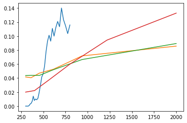

```python
plt.plot(Ts,pop_pt,label="pt")
plt.plot(Ts[0]/lambdas,pop_hrex,label="hrex")
plt.plot(Ts[0]/lambdas,pop_wham,label="wham")
plt.plot(Ts[0]/optimal_lambdas,pop_metad,label="metad+wham")
plt.show()
```

Weird, there is some difference. I now test the result using individual replicas

```python
pop_metad_single=[]
for i in range(6):
    colvar1=colvar_cat[1001*i:1001*(i+1)]
    weights1=np.exp((bias[1001*i:1001*(i+1),i]-np.max(bias[1001*i:1001*(i+1),i]))/kBT)
    weights1=np.exp(weights1)
    weights1/=np.sum(weights1)
    pop_metad_single.append(
        np.sum(weights1*np.logical_and(colvar1<2.0,colvar1>0))/
        np.sum(weights1*np.logical_or(colvar1>2.0,colvar1<0))
    )
```

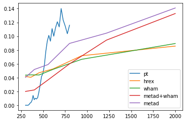

```python
plt.plot(Ts,pop_pt,label="pt")
plt.plot(Ts[0]/lambdas,pop_hrex,label="hrex")
plt.plot(Ts[0]/lambdas,pop_wham,label="wham")
plt.plot(Ts[0]/optimal_lambdas,pop_metad,label="metad+wham")
plt.plot(Ts[0]/optimal_lambdas,pop_metad_single,label="metad")
plt.legend()
plt.show()
```

Likely there is some convergence problem at small lambda!